{% raw %}

# 1. Milestone Project 1: 🍔👁 Food Vision Big

In the previous notebook, we only did 10% of the full 101 class of data. But what about 100% of the data?

We will be utilizing all 75,750 training images and 25,250 testing images.

Our goal is to beat the [DeepFood](https://www.researchgate.net/publication/304163308_DeepFood_Deep_Learning-Based_Food_Image_Recognition_for_Computer-Aided_Dietary_Assessment) paper, with an accuracy of 77.4% with 2-3 days of model training for top-1 accuracy.

> top-1 accuracy means looking the top 1 score, out of the possible classes (of 101), that has the true label. If it's top-5, then the top 5 scores, where true label has to be present in one of the 5 top options. This makes top-5 accuracy have noticeably higher scores than just top-1.

Alongside the attempt to beat `DeepFood`, we'll also be learning about Prefetching and Mixed precision training.

### What we're covering:

- Using TensorFlow Datasets to download and explore data
- Creating preprocessing function for our data
- Batching and preparing datasets for modelling (**making our datasets run fast**)
- Creating modelling callbacks
- Setting up **mixed precision training**
- Building a feature extraction model (see transfer learning part 1: feature extraction)
- Fine-tuning the feature extraction model (see transfer learning part 2: fine-tuning)

### GPU for mixed precision

Because I've tried mixed precesion on the homework of notebook 05, there is no way in hell my setup will run the model in training.

The study material pretty much suggests or assumes we're using google collab. Since I always want to keep paper records and autonomous control with my work, best idea is to create everything needed for the model, and somehow save and load the material onto google colab.

```python
!nvidia-smi -L
```

```
GPU 0: NVIDIA GeForce GTX 1060 6GB (UUID: GPU-2df24105-ee45-6c5e-c952-e600a0128c08)
```

Mixed precision works on TensorFlow 2.4.0+. Let's check our version

```python
# check tensorflow version
import tensorflow as tf
print(f'Tensorflow version: {tf.__version__}')

import datetime
print(f'Notebook last run (end-to-end): {datetime.datetime.now()}')
```

```
Tensorflow version: 2.13.0
Notebook last run (end-to-end): 2025-11-21 21:23:35.875179
```

### Get helper functions

pull in the python helper function scripts, to save on time from needing to rewrite code that are useful for our notebook.

```python
# get helper_functions.py script from course Github
!curl -O https://raw.githubusercontent.com/mrdbourke/tensorflow-deep-learning/main/extras/helper_functions.py

# import helper functions we're going to use
import sys, os
sys.path.append(os.getcwd())
import sklearn


from helper_functions import create_tensorboard_callback, plot_loss_curves, compare_historys
```

```
  % Total    % Received % Xferd  Average Speed   Time    Time     Time  Current
                                 Dload  Upload   Total   Spent    Left  Speed

  0     0    0     0    0     0      0      0 --:--:-- --:--:-- --:--:--     0
100 10246  100 10246    0     0  17094      0 --:--:-- --:--:-- --:--:-- 17191
```

### Use TensorFlow Datasets to Download Data

In previous notebooks, we've downloaded our food images from google storage.

There's another way to get datasets ready for TensorFlow.

The most popular datasets in machine learning world (often used as a benchmark), can be accessed through [TensorFlow Datasets (TFDS)](https://www.tensorflow.org/datasets/overview).

What is **TensorFlow Datasets**?

A place for prepeared and ready-to-use machine learning datasets.

Why use TensorFlow Datasets?

- Load data already in Tensors
- Practice on well established datasets
- Experiment with different data loading techniques (like we're going to use in this notebook)
- Experiment with new TensorFlow features quickly (such as mixed precision training)

Why *not* use TensorFlow Datasets?

- If the data is static (aka they don't change, like real-world datasets)
- Might not be suited to your problems (but great for experimentation)

```python
pip install tensorflow-datasets
```

```python
# get tensorflow datasets
import tensorflow_datasets as tfds
```

To find the available datasets, you can use `list_builders()` method.

We can then check if `food101` is present.

```python
# Get all available datasetsin TFDS
datasets_list = tfds.list_builders()

# set our target dataset and see if it exists
target_dataset = 'food101'
print(f"'{target_dataset}' in TensorFlow datasets: {target_dataset in datasets_list}")
```

```
'food101' in TensorFlow datasets: True
```

Looks like our desired dataset exists! To access it, we use `tfds.load()` method.

We'll have to pass a few parameters to let it know what we're after:

- `name` (str): the target dataset (e.g. `"food101"`)
- `split` (list,optional): which split of the data we're after (e.g. `"train"` or `"test"`)
  - the `split` parameter is quite tricky. Here's the [documentation.](https://github.com/tensorflow/datasets/blob/master/docs/splits.md)
- `shuffle_files` (bool): To whether shuffle or not on the files. Default is `False`.
- `as_supervised` (bool): `True` to download data samples in tuple format `(data, label)` or `False` for dictionary format.
- `with_info` (bool): `True` to download dataset metadata (labels, number of samples, etc)

```python
import os
os.environ["TFDS_DATA_DIR"] = r"X:\tensorflow_datasets"
```

```python
import tensorflow_datasets as tfds
tfds.core.constants.DATA_DIR
```

```
'C:\\Users\\deanc\\tensorflow_datasets'
```

```python
# load in data (takes 5-6 min)
(train_data, test_data), ds_info = tfds.load(name='food101', # target dataset from tfds
                                             split=['train', 'validation'], # which split of data we want
                                             shuffle_files=True, # shuffle files when downloaded?
                                             as_supervised=True, # download data in typle format (sample, label)
                                             with_info=True) # include dataset d
```

After waiting a few mins for the data to be downloaded, we now have access to the full `Food101` dataset (in Tensor format), ready for modelling.

Let's get some info from the dataset, starting with class names.

We can access class names of a particular dataset using the `dataset_info.features()` attribute and accessing `names` attribute of the `label` key.

```python
# features of Food101 TFDS
ds_info.features
```

```
FeaturesDict({
    'image': Image(shape=(None, None, 3), dtype=uint8),
    'label': ClassLabel(shape=(), dtype=int64, num_classes=101),
})
```

```python
# Get Class names
class_names = ds_info.features['label'].names
class_names[:10]
```

```
['apple_pie',
 'baby_back_ribs',
 'baklava',
 'beef_carpaccio',
 'beef_tartare',
 'beet_salad',
 'beignets',
 'bibimbap',
 'bread_pudding',
 'breakfast_burrito']
```

### Exploring the Food101 data from TensorFlow Datasets

Now we spent an eternity download this thing that decides to download a zipped version, then slowly unzip the photos, with some loading files? (Honestly seems extremely counterintuitive, time and space consuming to load file this way), let's do some data exploration.

In other words, 'visualize, visualize, visualize'.

Let's find out a few details about the dataset:

- Shape of our input data (image tensors)
- The datatype of input data
- What the labels of our input data look like (e.g. one-hot encoded versus label-encoded)
- Do the labels match up with the class names?

To do, ket's take one sample off the training data (using `.take()` [method](https://www.tensorflow.org/api_docs/python/tf/data/Dataset#take)) and explore it.

```python
# take one sample off the training data
train_one_sample = train_data.take(1) # samples are in format (image_tensor, label)
```

Because we used the `as_supervised=True` parameter in our `tfds.load()`, data samples come in tuple format `(data, label)`, for our case `(image_tensor, label)`.

```python
# what does one sample of our training data look like?
train_one_sample
```

```
<_TakeDataset element_spec=(TensorSpec(shape=(None, None, 3), dtype=tf.uint8, name=None), TensorSpec(shape=(), dtype=tf.int64, name=None))>
```

Let's loop through the single training sample, to get info of `image_tensor` and `label`.

```python
# output info about our training sample
for image, label in train_one_sample:
    print(f'''
    Image shape: {image.shape}
    Image dtype: {image.dtype}
    Target class from Food101 (tensor form): {label}
    Class name (str form): {class_names[label.numpy()]}
          ''')
```

```
    Image shape: (512, 384, 3)
    Image dtype: <dtype: 'uint8'>
    Target class from Food101 (tensor form): 19
    Class name (str form): chicken_quesadilla
```

Because of our use of `shuffle_files=True` parameter in our `tfds.load()`, running the cell multiple times will give us a random result each time.

You may also notice the `image.shape` also gives different shapes, such as `(512,512,3)` or `(512,384,3)` > (height, width, color_channels).

Let's see what one of the image tensors from TFDS's Food101 dataset looks like.

```python
# what does an image tensor from TFDS's Food101 look like?
image
```

```
<tf.Tensor: shape=(512, 384, 3), dtype=uint8, numpy=
array([[[  0,   0,   0],
        [  0,   0,   0],
        [  0,   0,   0],
        ...,
        [  7,   7,   5],
        [ 11,  11,   9],
        [ 14,  14,  12]],

       [[  0,   0,   0],
        [  0,   0,   0],
        [  0,   0,   0],
        ...,
        [  5,   5,   3],
        [  8,   8,   6],
        [ 11,  11,   9]],

       [[  0,   0,   0],
        [  0,   0,   0],
        [  0,   0,   0],
        ...,
        [  5,   5,   3],
        [  7,   7,   5],
        [ 10,  10,   8]],

       ...,

       [[ 72,  75,  82],
        [ 55,  58,  65],
        [ 43,  46,  51],
        ...,
        [105, 113, 115],
        [108, 113, 116],
        [135, 140, 143]],

       [[ 75,  80,  86],
        [ 61,  66,  72],
        [ 51,  54,  59],
        ...,
        [102, 107, 110],
        [ 75,  79,  82],
        [111, 115, 118]],

       [[ 94,  99, 105],
        [ 81,  86,  92],
        [ 71,  74,  79],
        ...,
        [151, 156, 159],
        [112, 116, 119],
        [111, 115, 118]]], dtype=uint8)>
```

```python
# What are the min max values?
tf.reduce_min(image), tf.reduce_max(image)
```

```
(<tf.Tensor: shape=(), dtype=uint8, numpy=0>,
 <tf.Tensor: shape=(), dtype=uint8, numpy=255>)
```

Our image has values between 0 and 255. Standard for RGB colour values, with the datatype of `unit8`.

We may preprocess them before training on them, but let's have a look at the image sample.

### Plot an image from TensorFlow Datasets

We've seen our image tensors in tensor format, now let's visualize it.

Plotting is done with `matplotlib.pyplot.imshow()`. Let's alsoprint the target class as the title.

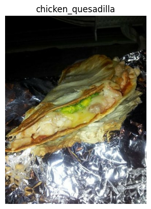

```python
# plot an image tensor
import matplotlib.pyplot as plt
plt.imshow(image)
plt.title(class_names[label.numpy()]) # add title to image by indexing to the class_names list
plt.axis(False);
```

Looks like the data of Food101, is similar to the dataset from our previous notebooks. Let's get it preprocessed for training.

### Create preprocessing functions for our data

In previous notebooks, when our images were in folder format, we used the format `tf.keras.utils.image_dataset_from_directory()` to load them.

This makes it format ready. But from downloading from TensorFlow Datasets, there are a couple of preprocessing steps we need to do before it is ready.

Currently, our data is:

- In `unit8` data type
- Comprised of all different sized tensors
- Pixel value not scaled

While models like data as:

- In `float32` data type
- All the same sized tensors
- Scaled to 0 to 1

To take care of these, we'll create a `preprocess_img()` function which:

- Resizes all tensors to a specific size using `tf.image.resize()`
- Converts an input image tensor's current datatype to `tf.float32` using `tf.cast()`

> **Note**: Pretrained EfficientNetBX models in `tf.keras.applications.efficientnet` have rescaling built in. But many others need to be rescaled manually, which can be incorporated into `preprocess_img()` function. Or in model via `tf.keras.layers.Rescaling` layer.

```python
# make a function for preprocessing images
def preprocess_img(image, label, img_shape=224):
    '''
    Converts image datatype from 'unit8' -> 'float32' and reshapes image to:
    [img_shape,img_shape,colour_channels]
    '''
    image=tf.image.resize(image, [img_shape,img_shape]) # reshape to img_shape
    return tf.cast(image, tf.float32), label # return (float32_image, label) tuple
```

Our `preprocess_img()` function above takes image and label as input, as our data is a tuple when loaded in vie Tensor Dataset, and is hardwired to see the 2 variables due to our use of `as_supervised=True`. (Even if you only wanted to change the image OR the label, not both)

Let's try our function out on a target image.

```python
# preprocess a single sample image and check the outputs
preprocessed_img = preprocess_img(image,label)[0] #[0] > we're just grabbing the first indexed variable, aka our `image`
print(f"Image before preprocessing:\n {image[:2]}...,\n Shape: {image.shape},\n Datatype: {image.dtype}\n") # [:2], gives us the first 2 rows of pixel value. We only want to see a bit of it, aka our visualize
print(f"Image after preprocessing:\n {preprocessed_img[:2]}...,\n Shape: {preprocessed_img.shape},\n Datatype: {preprocessed_img.dtype}")
```

```
Image before preprocessing:
 [[[ 0  0  0]
  [ 0  0  0]
  [ 0  0  0]
  ...
  [ 7  7  5]
  [11 11  9]
  [14 14 12]]

 [[ 0  0  0]
  [ 0  0  0]
  [ 0  0  0]
  ...
  [ 5  5  3]
  [ 8  8  6]
  [11 11  9]]]...,
 Shape: (512, 384, 3),
 Datatype: <dtype: 'uint8'>

Image after preprocessing:
 [[[ 0.         0.         0.       ]
  [ 0.         0.         0.       ]
  [ 0.         0.         0.       ]
  ...
  [ 7.7907934  7.7907934  5.7907934]
  [ 5.714286   5.714286   3.7142856]
  [10.999987  10.999987   8.999987 ]]

 [[ 0.         0.         0.       ]
  [ 0.         0.         0.       ]
  [ 0.         0.         0.       ]
  ...
  [ 6.770399   6.770399   4.770399 ]
  [ 6.790833   6.790833   4.790833 ]
  [10.1887665 10.1887665  8.1887665]]]...,
 Shape: (224, 224, 3),
 Datatype: <dtype: 'float32'>
```

Awesome! It's doing as expected, converting our `img_shape` to (224,224), and also changing it to `float32`.

How does the image look now?

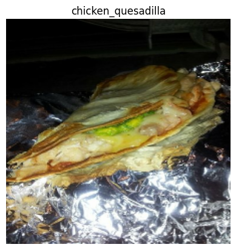

```python
# We can plot our preprocessed img, REMEMBER to /255. it or else it'll look wrong
plt.imshow(preprocessed_img/255.)
plt.title(class_names[label])
plt.axis(False);
```

What changing `/255.` does:

```
WARNING:matplotlib.image:Clipping input data to the valid range for imshow with RGB data ([0..1] for floats or [0..255] for integers). Got range [0.0..51.0].
```

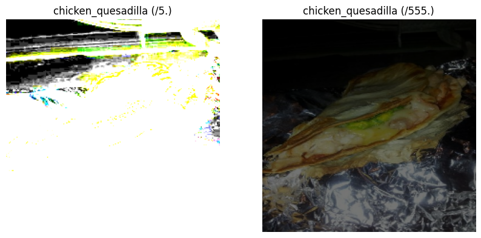

```python
plt.figure(figsize=(10, 5))

plt.subplot(1, 2, 1) # position in space for our plots
                     #(row num, column num, index locality - it's pos is dictated from left to right, up to down)
plt.imshow(preprocessed_img/5.0)
plt.title(f"{class_names[label]} (/5.)")
plt.axis("off")

plt.subplot(1, 2, 2)
plt.imshow(preprocessed_img/555.0)
plt.title(f"{class_names[label]} (/555.)")
plt.axis("off")

plt.show()
```

It changes brightness of photo!

### Batch and prepare datasets

First, we need to compute in batches to create memory efficiency.

We'll turn 101,000 images into batches of 32 image and label pairs. We will use methods such as `tf.data` API.

> **Resource**: When loading data in the most performant way possible, here's a documentation for reading if needed: [Better performance with the tf.data API](https://www.tensorflow.org/guide/data_performance)

We'll be using:

- `map()` - maps a predefined function to a target dataset (e.g. `preprocess_img()` to our image tensors)
- `shuffle()` - randomly shuffles elements in a dataset. Uses `buffer_size` (ideally, `buffer_size` is equal to size of dataset, though may have implications on memory)
- `batch()` - turns elements of a target dataset into batches (size is defined by parameter `batch_size`)
- `prefretch()` - prepares subsequent batches of data whilst other batches of data are being computed (improves data loading speed, though costs more memory)
- Extra: `cache()` - Catches (saves them for later) elements in a target dataset, saving loading time (only works for small enough dataset that can fit into memory)

Things to note:

- You can't batch tensors of **different** shapes (e.g. different image size - and must be the same size)
- `shuffle()` keeps a buffer of a number of images to be shuffled while data is being used, ideally this number would be all of the samples in your training set. If you training set is large, buffer might not fit in memory. (A fairly large number like 1,000 or 10,000 is usually suffice for shuffling - what it does is shuffling an area of the data, at an area where the model is training, while outside stays the same)
- For methods with the `num_parallel_calls` parameter available (such as `map()`), setting it to `num_parallel_calls=tf.data.AUTOTUNE` will parallelize preprocessing and significantly improve speed.
  - Aka, the computer will run multiple images simultaneously between each other, rather than doing them in a single file order/queue (which causes bottlenecking). `AUTOTUNE` will choose the optimal number of cells to run in parallel, based on your CPU/GPU hardware, rather than you having to guess it yourself.
- Can't use `cache()` unless your dataset can fit in memory.

It's alot, but once we've coded below, it'll make sense.

We're going through things in the following order:

`Original dataset (e.g. train_data) -> map() -> shuffle() -> batch() -> prefetch() -> PrefetchDataset`

This is like saying:

> Hey computer - map this preprocessing function across our training dataset, then shuffle a number of elements before batching them together, and make sure you prepare new batches (prefetch) whilst the model is looking through the current batch.

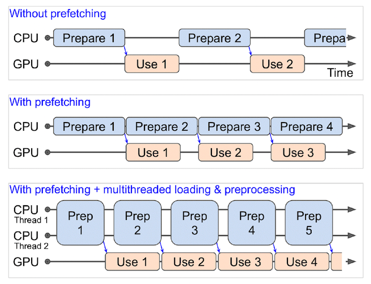

```python
from IPython.display import Image, display
display(Image(filename="68747470733a2f2f7261772e67697468756275736572636f6e74656e742e….png"))
```

*What happens when you use prefetching (which are faster) vs. what happens when you don't use prefetching (slower).* *Source**: Page 422 of [Hands-On Machine Learning with Scikit-Learn, Keras and TensorFlow Book.](https://www.oreilly.com/library/view/hands-on-machine-learning/9781492032632/)*

```python
# Map preprocesing function to training data (and paralellize)
train_data = train_data.map(map_func=preprocess_img, num_parallel_calls=tf.data.AUTOTUNE)
# Shuffle train_data and turn it into batches and prefetch it (load it faster)
train_data = train_data.shuffle(buffer_size=1000).batch(batch_size=32).prefetch(buffer_size=tf.data.AUTOTUNE)

# Map preprocessing function to test data
test_data = test_data.map(preprocess_img, num_parallel_calls=tf.data.AUTOTUNE)
# Turn test data into batches (don't need to shuffle)
test_data = test_data.batch(32).prefetch(tf.data.AUTOTUNE)
```

Let's check out what our prepared dataset looks like.

```python
train_data, test_data
```

```
(<_PrefetchDataset element_spec=(TensorSpec(shape=(None, 224, 224, 3), dtype=tf.float32, name=None), TensorSpec(shape=(None,), dtype=tf.int64, name=None))>,
 <_PrefetchDataset element_spec=(TensorSpec(shape=(None, 224, 224, 3), dtype=tf.float32, name=None), TensorSpec(shape=(None,), dtype=tf.int64, name=None))>)
```

Excellent! Looks like our data is now in tuples of `(image, label)` with datatypes of `(tf.float32, tf.int64)`, just what our model is after.

> **Note**: You can get away without calling the `prefetch()` method on the end of your datasets. However you'd probably see significantly slower data loading speeds when building a model. So most of your dataset input pipeline should end with a call to `prefetch()`.

### Create modelling callbacks

Due to how large the data is, it's essential to have modelling callbacks to track model training logs, or being chckpointed (saved) after various training milestones.

To do so, we'll use the following callbacks:

- `tf.keras.callbacks.TensorBoard()` - allows us to keep track of model's training history for later inspection
- `tf.keras.callbacks.ModelCheckpoint()` - saves our model's progress at any interval, where we can load it and reuse/continue training without having to redo it from start.
  - Checpoint is also useful if we feel like we want to go back to a particular epoch, and revert it to that previous stae, rather than it's current fully trained self.

```python
# create tensorboard callback (already have 'create_tensor_callback()' from previous notebook)
from helper_functions import create_tensorboard_callback

# create ModelCheckpoint callback to save model's progress
checkpoint_path = 'model_checkpoints/cp.ckpt' # saving weights requires '.ckpt' extension
model_checkpoint = tf.keras.callbacks.ModelCheckpoint(checkpoint_path,
                                                      monitor='val_accuracy', # saving the model weights from the best validation accuracy
                                                      save_best_only=True, # only save the best weights
                                                      save_weights_only=True, # only save model weights (not all the layers etc.)
                                                      verbose=0) # don't print out whether or not the model is being saved
```

### Setup mixed precision training

We've learnt a little bit about it with `06 homework`.

TensorFlow normally uses `float32`, aka uses 32 bits to compute each weight value. This is a limit that GPU memories can handle. But we got mixed precision.

This uses a mix of `float16` and `float32` to make better use of GPU memory, as it uses *half* the bits (16 bits) for each weight value.

This mixture of use allows the computer to use less memory wherever possible to run faster (aka, more tensors can be computed simultaneously, increasing training speed).

More info can be read at: [TensorFlow mixed precision guide](https://www.tensorflow.org/guide/mixed_precision)

Let's see how mixed precision training is implemented on TensorFlow.

First we'll import the API and then use the `set_global_policy()` method to set the *dtype policy* to `'mixed_float16'`.

```python
# Turn on mixed precision training
from tensorflow.keras import mixed_precision
mixed_precision.set_global_policy(policy='mixed_float16') # set global policy to mixed precision
```

```
WARNING:tensorflow:Mixed precision compatibility check (mixed_float16): WARNING
The dtype policy mixed_float16 may run slowly because this machine does not have a GPU. Only Nvidia GPUs with compute capability of at least 7.0 run quickly with mixed_float16.
If you will use compatible GPU(s) not attached to this host, e.g. by running a multi-worker model, you can ignore this warning. This message will only be logged once
```

[output not shown]

Of COURSE we get an error, cuz dumbass shitty TensorFlow can't recognize my GPU despite how much I've tried. We'll copy paste the code work onto `Google Collab` when we reach the training phase.

Let's check the global dtype policy (the policy which will be used by layers in our model) using the `mixed_precision.global_policy()` method.

```python
mixed_precision.global_policy() # should output 'mixed_float16'
```

```
<Policy "mixed_float16">
```

Since the global dtype is `mixed_float16`, our model will take advantage of float 16 variabls where possible and in turn, speed up training.

### Build feature extraction model

Let's start building a model.

Due to how large the dataset is, we're going to move towards fine-tuning an existing pretrained model. (EfficientNetB0).

Before fine-tuning, let's set up the feature extraction model first. As a refresher of the steps to build one:

- Use `EfficientNetB0` from `tf.keras.applications` pre-trained on ImageNet as our base model.
  - We'll download this without the top layers using `include_top=False` parameter so we can create our own output layers.
- Freeze the base model layers, so we can utilize pre-trained weights/patterns of the original model.
- Put together the input, base model, pooling and output layers in a [Functional API model](https://keras.io/guides/functional_api/)
- Compile the Functional model using the Adam optimizer and [Sparse Categorical Crossentropy](https://www.tensorflow.org/api_docs/python/tf/keras/losses/SparseCategoricalCrossentropy) as the loss function (since our labels aren't one-hot encoded - and only need the index value of highest probability)
- Fit the model for 3 epochs using the TensorBoard and ModelCheckpoint callbacks

> **Note**: Due to mixed precision training - the model's output layer must stay as `dtype=float32`. For example, `layers.Activatioin('softmax', dtype=tf.float32)`. This insures the outputs of our model are returned back to the float 32 data type, which is more numerically stable than `float16`. Very crucial for loss calculation, as numbers tend to be extremely big, and `float16` is not able to accomodate it, often returning a value of `inf`.

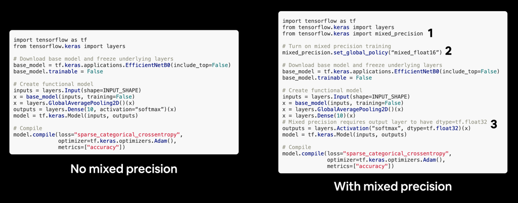

```python
display(Image(filename="68747470733a2f2f7261772e67697468756275736572636f6e74656e742e….png"))
```

*Mixed precision is turned on via the labeled 3 lines of code*

```python
from tensorflow.keras import layers

# create base model
input_shape=(224,224,3)
base_model=tf.keras.applications.EfficientNetB0(include_top=False)
base_model.trainable=False # freeze base model layer weights

# Create functional API model
inputs = layers.Input(shape=input_shape, name='input_layer')
# Note: EfficientNetBx - has built in rescaling. However if your base model doesn't have that, include:
# x = layers.Rescaling(1./255)(x)
x = base_model(inputs, training=False) # set base_model to inference mode, where normalization, dropout etc. weights that influence other weights are frozen
x = layers.GlobalAveragePooling2D(name='pooling_layer')(x)
x = layers.Dense(len(class_names))(x) # want one output neuron per class (making 101 neurons)

outputs = layers.Activation('softmax', dtype=tf.float32, name='softmax_float32')(x) # remember that output MUST be float32 to work
model = tf.keras.Model(inputs,outputs)

# compile the model
model.compile(loss='sparse_categorical_crossentropy', # use only when labels are not one-hot encoded
              optimizer=tf.keras.optimizers.Adam(),
              metrics=['accuracy'])
```

```python
# check out our model
model.summary()
```

[output not shown]

### Checking layer dtype policies (are we using mixed precision?)

We said how mixed precision API will automatically change the layers' dtype policy to whatever global dtype we set it to (aka. `mixed_float16`).

We can check this by iterating through the model layers, and check the `dtype` and `dtype_police`.

```python
# check the dtype_policy sttributes of layers in our model
for layer in model.layers:
    print(layer.name, layer.trainable, layer.dtype, layer.dtype_policy) # check the dtype policy of layers
```

```
input_layer True float32 <Policy "float32">
efficientnetb0 False float32 <Policy "mixed_float16">
pooling_layer True float32 <Policy "mixed_float16">
dense True float32 <Policy "mixed_float16">
softmax_float32 True float32 <Policy "float32">
```

Looking at the above, the variables are from left to right:

- `layer.name` (str): A readable name for humans - can be definied by the `name` parameter on contruction
- `layer.trainable` (bool): Whether or not the layer is trainable
- `layer.dtype`: The data type the layer stores its variables in
- `layer.dtype_policy`: The data type the layer computes in

> **Note**: A layer can have a dtype of `float32` and a dtype policy of `'mixed_float16'` because it stores its variables in `float32` (more numerically stable), however it computes in `float16` (which is faster).

We can check the same details for our model's `base model`.

```python
# check the layers in the base model and see what dtype policy they're using
for layer in model.layers[1].layers[:20]: # only check the first 20 layers
    # note: model.layer[1] - we're getting the indexed location of 1 from functional api model (which is base model), then going into the model to get the first 20 layers based on [:20]
    print(layer.name,layer.trainable,layer.dtype,layer.dtype_policy)
```

```
input_1 False float32 <Policy "float32">
rescaling False float32 <Policy "mixed_float16">
normalization False float32 <Policy "mixed_float16">
rescaling_1 False float32 <Policy "mixed_float16">
stem_conv_pad False float32 <Policy "mixed_float16">
stem_conv False float32 <Policy "mixed_float16">
stem_bn False float32 <Policy "mixed_float16">
stem_activation False float32 <Policy "mixed_float16">
block1a_dwconv False float32 <Policy "mixed_float16">
block1a_bn False float32 <Policy "mixed_float16">
block1a_activation False float32 <Policy "mixed_float16">
block1a_se_squeeze False float32 <Policy "mixed_float16">
block1a_se_reshape False float32 <Policy "mixed_float16">
block1a_se_reduce False float32 <Policy "mixed_float16">
block1a_se_expand False float32 <Policy "mixed_float16">
block1a_se_excite False float32 <Policy "mixed_float16">
block1a_project_conv False float32 <Policy "mixed_float16">
block1a_project_bn False float32 <Policy "mixed_float16">
block2a_expand_conv False float32 <Policy "mixed_float16">
block2a_expand_bn False float32 <Policy "mixed_float16">
```

> **Note**: The mixed precision API automatically causes layers which can benefit from using the `mixed_float16` dtype policy to use it. It also prevents layers which shouldn't use it from using it (e.g. normalization layer at the start of the base model).

### Fit the feature extraction model

Let's fit the data in :)

Three epochs should be enough for the top layers to adjust their weights enough to our food image data.

To save time per epoch, only 15% of validation data is used during test.

```python
# Turn off all warnings except for errors
tf.get_logger().setLevel('ERROR')

# fit the model with callbacks
history_101_food_classes_feature_extract = model.fit(train_data,
                                                     epochs=3,
                                                     steps_per_epoch=len(train_data),
                                                     validation_data=test_data,
                                                     validation_steps=int(0.15*len(test_data)),
                                                     callbacks=[create_tensorboard_callback('training_logs',
                                                                                            'efficientnetb0_101_classes_all_data_feature_extract'),
                                                                                            model_checkpoint])
```

```
Saving TensorBoard log files to: training_logs/efficientnetb0_101_classes_all_data_feature_extract/20251123-111513
```

[output not shown]

[output cut: 59 more lines]

[output not shown]

Obviously we won't be training on my computer because it's pretty dumb to train an epoch for close to 3 damn hours. So we'll see if I can migrate content into google collab, do the training, and pull everything back in.

So far, I've copy pasted all relevant codes onto colab for the model to be trained successfully for 3 epochs.

### All code is continued on colab

I realized, that anything beyond here likely will not be ran on my VScode instance, due to hardware limitation, and also not being able to complete this training step.

All code from here will be copy paste into colab, and I will then copy paste colab's results underneath the code block, to give a better understanding of what the outputs are.

```
Saving TensorBoard log files to: training_logs/efficientnetb0_101_classes_all_data_feature_extract/20251202-032308
Epoch 1/3
2368/2368 ━━━━━━━━━━━━━━━━━━━━ 279s 92ms/step - accuracy: 0.4771 - loss: 2.2929 - val_accuracy: 0.6976 - val_loss: 1.1339
Epoch 2/3
2368/2368 ━━━━━━━━━━━━━━━━━━━━ 221s 69ms/step - accuracy: 0.6670 - loss: 1.2833 - val_accuracy: 0.7097 - val_loss: 1.0366
Epoch 3/3
2368/2368 ━━━━━━━━━━━━━━━━━━━━ 169s 70ms/step - accuracy: 0.7032 - loss: 1.1371 - val_accuracy: 0.7246 - val_loss: 0.9935
```

```python
# evaluate model on whole test dataset
results_feature_extract_model = model.evaluate(test_data)
results_feature_extract_model
```

```
790/790 ━━━━━━━━━━━━━━━━━━━━ 75s 95ms/step - accuracy: 0.7243 - loss: 1.0032
[1.0023367404937744, 0.7276831865310669]
```

Since we have used the `ModelCheckpoint` callback, we've got a saved version of this model in the `model_checkpoints` directory.

Let's load in the model from colab, into this pc.

### Load and evaluate checkpoint weights

We can load it in and evaluate our model's checkpoints by:

1. Recreating a new instance of our model called `created_model` by turning our original model creation code into a function called `create_model()`.
2. Compiling our `created_model` with the same loss, optimizer and metrics as the original model (every time you create a new model, you must compile it).
3. Calling the `load_weights()` method on our `created_model` and passing it the path to where our checkpointed weights are stored.
4. Calling `evaluate()` on `created_model` with loaded weights and saving the results.
5. Comparing the `created_model` results to the previous `model` results (should be the exact same or extremely close).

A reminder, checkpoints are helpful when you perform experiments on a model. If the experiment turned out to make the model even worse, you can always revert it back to when you haven't done the experiment.

> **Note**: `tf.keras.clone_model` was previously used in the loading model part, but came with some errors. There is a [github discussion](https://github.com/mrdbourke/tensorflow-deep-learning/discussions/550) from the creator of he course regarding it.

```python
# 1. Create a function to recreate the original model
def create_model():
    # create a base model
    input_shape = (224,224,3)
    base_model = tf.keras.applications.efficientnet.EfficientNetB0(include_top=False)
    base_model.trainable=False # freeze base model layers

    # create functional model
    inputs = layers.Input(shape=input_shape,name='input_layer')
    # x = layers.Rescaling(1./255)(x) # < use if model doesn't come with rescaling
    x = base_model(inputs,training=False) # set base_model to inference mode
    x = layers.GlobalAveragePooling2D(name='pooling_layer')(x)
    x = layers.Dense(len(class_names))(x) # one output neuron per class
    # output layer must be float32
    outputs = layers.Activation('softmax',dtype=tf.float32,name='softmax_float32')(x)
    model = tf.keras.Model(inputs,outputs)

    return model

# 2. Create and compile a new version of the original model (new weights)
created_model = create_model()
created_model.compile(loss='sparse_categorical_crossentropy',
                      optimizer=tf.keras.optimizers.Adam(),
                      metrics=['accuracy'])

# 3. Load the saved weights
created_model.load_weights(checkpoint_path)

# 4. Evaluate the model with loaded weights
results_created_model_with_loaded_weights = created_model.evaluate(test_data)
```

```
/usr/local/lib/python3.12/dist-packages/keras/src/saving/saving_lib.py:802: UserWarning: Skipping variable loading for optimizer 'loss_scale_optimizer', because it has 4 variables whereas the saved optimizer has 10 variables.
  saveable.load_own_variables(weights_store.get(inner_path))
/usr/local/lib/python3.12/dist-packages/keras/src/saving/saving_lib.py:802: UserWarning: Skipping variable loading for optimizer 'adam', because it has 2 variables whereas the saved optimizer has 6 variables.
  saveable.load_own_variables(weights_store.get(inner_path))
790/790 ━━━━━━━━━━━━━━━━━━━━ 91s 86ms/step - accuracy: 0.7245 - loss: 1.0033
```

The results from the loaded weights should be very close to the feature extraction model's results.

```python
# 5. Loaded checkpoint weights should return very similar results to checkpoint weights prior to saving
import numpy as np
assert np.isclose(results_feature_extract_model, results_created_model_with_loaded_weights).all(), 'Loaded weights results are not close to original model.'
# to check if all elements in array are close - string text is a raised error, if both models are not close to each other.
```

Cloning the model preserves `dtype_policy` of layers (but not the weights) so if we wanted to continued to fine-tune our model, we could still use the mixed precision dtype policy, without having to call on it again.

```python
# check the layers in the base model and see what dtype policy they're using
for layers in model.layers[1].layers[:20]: # check only the first 20 layers to save printing space
    print(layer.name,layer.trainable,layer.dtype,layer.dtype_policy)
```

[output not shown]

### Save the whole model to file

We can also save the whole model using `save()` method.

On google colab, there's an option to osave the model file to google drive itself, for use outside of the colab environment.

```python
# saving model to google drive

# create save path to drive
save_dir = 'drive/MyDrive/tensorflow'
os.makedirs(save_dir) # make directory if it doesn't exist

# save model
model.save(save_dir)
```

There's another option of saving on colab itself for easier access, but will delete itself if environment is not used, making you have to redo everything again.

```python
# save model locally
# save_dir = '07_efficientb0_feature_extract_model_mixed_precision
# model.save(save_dir)
```

And again, we can check whether or not our model saved correctly by loading it in and evaluating it.

```python
# load model previously saved above
loaded_gs_model = tf.keras.models.load_model(save_dir)
```

Loading a `SavedModel` also retains all of the underlying layers `dtype_policy` (we want them to be `mixed_float16`).

```python
# Check the layers in the base model and see what dtype policy they're using
for layer in loaded_gs_model.layers[1].layers[:20]: # check only the first 20 layers to save output space
    print(layer.name, layer.trainable, layer.dtype, layer.dtype_policy)
```

[output not shown]

```python
# check loaded model performance (should be the same as results_feature_extract_model)
results_loaded_gs_model = loaded_gs_model.evaluate(test_data)
results_loaded_gs_model
```

[output not shown]

```
790/790 ━━━━━━━━━━━━━━━━━━━━ 82s 75ms/step - accuracy: 0.7239 - loss: 1.0042
[1.0023361444473267, 0.7276831865310669]
```

```python
  # the loaded model's results should equal or be very close to the model's prior results before saving occured
import numpy as np
assert np.isclose(results_feature_extract_model,results_loaded_gs_model).all()
```

Nice, our model is performing as it should!

> **Note**: We've spent a lot of time just making sure the model is saved correctly. This is due to the time consumption of training, and want to make sure what we have is the real deal, before redoing again.

### Preparing our model's layers for fine-tuning

Our feature extraction model has done well with just 3 epochs. With so much data though, it's worth checking the results for fine tuning as well.

> **Note**: Industry standards of doing fine-tuning, is you do feature-extraction for a few epochs, to get the output layer weights inline to our custom data. Once done, proceed to unfreeze the layers required for your experiment.

When the model was created, all layers in the base model had the setting `base_model.trainable=False`. Now that we loaded up the model, let's check whether it is trainable or not.

```python
# are any of the layers in our model frozen?
for layer in loaded_gs_model.layers:
    layer.trainable = True # set all layers to trainable
    print(layer.name, layer.trainable, layer.dtype, layer.dtype_policy) # make sure loaded model is using mixed precision dtype_policy ('mixed_float16')
```

```
input_layer True float32 <DTypePolicy "mixed_float16">
efficientnetb0 True float32 <DTypePolicy "mixed_float16">
pooling_layer True float32 <DTypePolicy "mixed_float16">
dense True float32 <DTypePolicy "mixed_float16">
softmax_float32 True float32 <DTypePolicy "float32">
```

Seems that all layers in our functional API model is trainable. Let's check in the base model's layers.

To access the base model, we can access them like each layer is indexed, aka `1`.

```python
# check the layers in the base model and see what dtype policy they're using
for layer in loaded_gs_model.layers[1].layers[:20]:
    print(layer.name, layer.trainable, layer.dtype, layer.dtype_policy)
```

```
input_layer True float32 <DTypePolicy "mixed_float16">
rescaling True float32 <DTypePolicy "mixed_float16">
normalization True float32 <DTypePolicy "mixed_float16">
rescaling_1 True float32 <DTypePolicy "mixed_float16">
stem_conv_pad True float32 <DTypePolicy "mixed_float16">
stem_conv True float32 <DTypePolicy "mixed_float16">
stem_bn True float32 <DTypePolicy "mixed_float16">
stem_activation True float32 <DTypePolicy "mixed_float16">
block1a_dwconv True float32 <DTypePolicy "mixed_float16">
block1a_bn True float32 <DTypePolicy "mixed_float16">
block1a_activation True float32 <DTypePolicy "mixed_float16">
block1a_se_squeeze True float32 <DTypePolicy "mixed_float16">
block1a_se_reshape True float32 <DTypePolicy "mixed_float16">
block1a_se_reduce True float32 <DTypePolicy "mixed_float16">
block1a_se_expand True float32 <DTypePolicy "mixed_float16">
block1a_se_excite True float32 <DTypePolicy "mixed_float16">
block1a_project_conv True float32 <DTypePolicy "mixed_float16">
block1a_project_bn True float32 <DTypePolicy "mixed_float16">
block2a_expand_conv True float32 <DTypePolicy "mixed_float16">
block2a_expand_bn True float32 <DTypePolicy "mixed_float16">
```

Wonderful, it looks like each layer in base model is unfrozen, and should be using the `mixed_float16` dtype policy.

With so much data (75750 training images), we will try running all the model's layers unfrozen.

> **Note**: with small amounts of data, its best to only unfreeze a small number of layers, otherwise you risk overfitting.

### A couple more callbacks

We're about to begin fine tuning a 200-layered model on over 100,000 images. Which will take a very long time. This may take a couple of hours, or even 2-3 days from the `DeepFood paper` (which is the baseline we're wanting to beat).

> **Question**: When should you stop training?

Ideally when the model stops improving. But with the nature of deep learning, it can be hard to know exactly when a model will stop improving. Fortunately, `Earlystopping` callback solves this issue.

The callback monitors the specified model performance metric (e.g. `val_loss`). When it stops improving for a specified number of epochs, training is automatically halted.

Using `EarlyStopping` and `ModelCheckpoint` callbacks, we could keep our model training for an unlimited number of epochs until it stops improving.

Let's set both of these up to monitor model's `val_loss`.

```python
# setup earlystopping callback to stop training if model's val_loss doesn't improve for 3 epochs
early_stopping=tf.keras.callbacks.EarlyStopping(monitor='val_loss', # watch the val loss metric
                                                patience=3) # if val loss doesn't improve for 3 epochs in a row, stop training

# create ModelCheckpoint callback to save best model during fine-tuning
checkpoint_path='fine_tune_checkpoints/'
model_checkpoint=tf.keras.callbacks.ModelCheckpoint(checkpoint_path,
                                                    save_best_only=True,
                                                    monitor='val_loss')
```

When training large models, `EarlyStopping` and `ModelCheckpoint` are absolutely essential to familiarize with.

Another callback we want to implement is: `ReduceLROnPlateau`.

You know how learning rate is the most important model hyperparameter there is? Well the `ReduceLROnPlateau` callback helps to tune the learning rate for you.

Like the other 2 callback metrics, `ReduceLROnPlateau` also tracks a specific metric. If such metric stops improving, it reduces the learning rate by a specified factor (e.g. dividing learning rate by 10).

> **Question**: Why the lowering of LR?

Analogy, if you got a coin at the back of the couch and you want to grab it, how are your motor skills changing during the grab? The further you are, the more forceful you are to pushing and moving through.

Then the closer you are, the more refined and smaller your movements are. Because if you move too suddenly and quickly like you did when pushing your way down, the coin may likely disappear from view too quickly and you need to search for it again.

Our model performance is similar to that. As our model gets closer and closer to it's ideal performance (convergence), then we want it to learn less and less, therefore making smaller and smaller movements.

To do this, we have the instance `ReduceLROnPlateau` callback to monitor validation loss.

Once validation loss stops improving for two or more epochs, we'll reduce LR by factor of 5. (e.g. 0.1 becomes 0.02).

We don't want LR to be too small, so will set a `1e-7` limit or else we get no movement from the model's LR.

```python
# creating learning rate reduction callback
reduce_lr = tf.keras.callbacks.ReduceLROnPlateau(monitor='val_loss',
                                                 factor=0.2, # multiply lr by 0.2
                                                 patience=2,
                                                 verbose=1, # prints out when lr is going down
                                                 min_lr=1e-7)
```

Before starting, we have to recompile the model since we've made changes to it.

We'll use sparse categorical crossentropy as the loss and since we're fine tuning, we'll use a 10x lower LR than the Adam optimizer's `1e-3` default.

```python
# compile the model
loaded_gs_model.compile(loss='sparse_categorical_crossentropy', # use for labels that are not one-hot encoded, but indexed
                        optimizer=tf.keras.optimizers.Adam(0.0001), # 10x smaller than default
                        metrics=['accuracy'])
```

Now let's fit it on the data and run it for 100 epochs.

Since we're using `EarlyStopping`, it may stop before reaching 100 epochs.

```python
# start to fine-tune all layers
history_101_food_classes_all_data_fine_tune = loaded_gs_model.fit(train_data,
                                                                  epochs=100, # fine tune a max of 100 epochs
                                                                  steps_per_epoch=len(train_data),
                                                                  validation_data=test_data,
                                                                  validation_steps=int(0.15*len(test_data)), # validation during training on 15% of test data
                                                                  callbacks=[create_tensorboard_callback('training_logs','efficientb0_101_classes_all_data_fine_tuning'), # track the model training logs
                                                                             model_checkpoint, # save only the best model during training
                                                                             early_stopping, # stop model after x epochs of no improvements
                                                                             reduce_lr]) # reduce lr after x epochs of no improvement
```

```
Saving TensorBoard log files to: training_logs/efficientb0_101_classes_all_data_fine_tuning/20251209-071208
Epoch 1/100
2368/2368 ━━━━━━━━━━━━━━━━━━━━ 566s 157ms/step - accuracy: 0.6238 - loss: 1.4720 - val_accuracy: 0.7987 - val_loss: 0.7210 - learning_rate: 1.0000e-04
Epoch 2/100
2368/2368 ━━━━━━━━━━━━━━━━━━━━ 227s 95ms/step - accuracy: 0.7977 - loss: 0.7564 - val_accuracy: 0.8170 - val_loss: 0.6651 - learning_rate: 1.0000e-04
Epoch 3/100
2368/2368 ━━━━━━━━━━━━━━━━━━━━ 261s 94ms/step - accuracy: 0.8545 - loss: 0.5362 - val_accuracy: 0.8242 - val_loss: 0.6453 - learning_rate: 1.0000e-04
Epoch 4/100
2368/2368 ━━━━━━━━━━━━━━━━━━━━ 228s 95ms/step - accuracy: 0.9010 - loss: 0.3739 - val_accuracy: 0.8249 - val_loss: 0.6371 - learning_rate: 1.0000e-04
Epoch 5/100
2368/2368 ━━━━━━━━━━━━━━━━━━━━ 226s 94ms/step - accuracy: 0.9292 - loss: 0.2686 - val_accuracy: 0.8361 - val_loss: 0.6288 - learning_rate: 1.0000e-04
Epoch 6/100
2368/2368 ━━━━━━━━━━━━━━━━━━━━ 263s 94ms/step - accuracy: 0.9496 - loss: 0.2032 - val_accuracy: 0.8279 - val_loss: 0.6583 - learning_rate: 1.0000e-04
Epoch 7/100
2367/2368 ━━━━━━━━━━━━━━━━━━━━ 0s 90ms/step - accuracy: 0.9619 - loss: 0.1509

Epoch 7: ReduceLROnPlateau reducing learning rate to 1.9999999494757503e-05.

2368/2368 ━━━━━━━━━━━━━━━━━━━━ 223s 93ms/step - accuracy: 0.9619 - loss: 0.1509 - val_accuracy: 0.8294 - val_loss: 0.6628 - learning_rate: 1.0000e-04
Epoch 8/100
2368/2368 ━━━━━━━━━━━━━━━━━━━━ 224s 94ms/step - accuracy: 0.9756 - loss: 0.1035 - val_accuracy: 0.8448 - val_loss: 0.6209 - learning_rate: 2.0000e-05
Epoch 9/100
2368/2368 ━━━━━━━━━━━━━━━━━━━━ 224s 93ms/step - accuracy: 0.9820 - loss: 0.0821 - val_accuracy: 0.8408 - val_loss: 0.6296 - learning_rate: 2.0000e-05
Epoch 10/100
2367/2368 ━━━━━━━━━━━━━━━━━━━━ 0s 90ms/step - accuracy: 0.9849 - loss: 0.0716

Epoch 10: ReduceLROnPlateau reducing learning rate to 3.999999898951501e-06.

2368/2368 ━━━━━━━━━━━━━━━━━━━━ 225s 94ms/step - accuracy: 0.9849 - loss: 0.0716 - val_accuracy: 0.8438 - val_loss: 0.6233 - learning_rate: 2.0000e-05
Epoch 11/100
2368/2368 ━━━━━━━━━━━━━━━━━━━━ 224s 94ms/step - accuracy: 0.9868 - loss: 0.0629 - val_accuracy: 0.8464 - val_loss: 0.6196 - learning_rate: 4.0000e-06
Epoch 12/100
2368/2368 ━━━━━━━━━━━━━━━━━━━━ 222s 93ms/step - accuracy: 0.9894 - loss: 0.0571 - val_accuracy: 0.8435 - val_loss: 0.6286 - learning_rate: 4.0000e-06
Epoch 13/100
2367/2368 ━━━━━━━━━━━━━━━━━━━━ 0s 91ms/step - accuracy: 0.9900 - loss: 0.0556

Epoch 13: ReduceLROnPlateau reducing learning rate to 7.999999979801942e-07.

2368/2368 ━━━━━━━━━━━━━━━━━━━━ 265s 94ms/step - accuracy: 0.9900 - loss: 0.0556 - val_accuracy: 0.8416 - val_loss: 0.6372 - learning_rate: 4.0000e-06
Epoch 14/100
2368/2368 ━━━━━━━━━━━━━━━━━━━━ 221s 92ms/step - accuracy: 0.9891 - loss: 0.0552 - val_accuracy: 0.8445 - val_loss: 0.6233 - learning_rate: 8.0000e-07
```

Let's make sure the model is saved before we start evaluation.

From the above, does it look like the model is over or underfitting? Remember when training loss is significantly lower than validation loss, it's a hint the model has overfit the training data, and not learnt generalizeable patterns in unseen data.

```python
results_loaded_gs_model = loaded_gs_model.evaluate(test_data)
results_loaded_gs_model
```

```
790/790 ━━━━━━━━━━━━━━━━━━━━ 64s 81ms/step - accuracy: 0.8391 - loss: 0.6468
[0.653698742389679, 0.8375841379165649]
```

```python
# Save model to google drive (optional)
loaded_gs_model.save('/content/drive/MyDrive/tensorflow')
```

### Download fine-tuned model from Google Storage

There is an already prepeared model from Google Storage, that is fine-tuned like the model we've just done. Lets import it and evaluate it.

```python
# download and evaluate fine-tuned model from Google Storage
!curl -O https://storage.googleapis.com/ztm_tf_course/food_vision/07_efficientnetb0_fine_tuned_101_classes_mixed_precision.zip
```

```
  % Total    % Received % Xferd  Average Speed   Time    Time     Time  Current
                                 Dload  Upload   Total   Spent    Left  Speed

  0     0    0     0    0     0      0      0 --:--:-- --:--:-- --:--:--     0
  0     0    0     0    0     0      0      0 --:--:-- --:--:-- --:--:--     0
  0 44.6M    0 17904    0     0  16895      0  0:46:09  0:00:01  0:46:08 16938
  1 44.6M    1  682k    0     0   335k      0  0:02:16  0:00:02  0:02:14  336k
 22 44.6M   22 10.1M    0     0  3431k      0  0:00:13  0:00:03  0:00:10 3434k
 48 44.6M   48 21.6M    0     0  5496k      0  0:00:08  0:00:04  0:00:04 5499k
 74 44.6M   74 33.2M    0     0  6767k      0  0:00:06  0:00:05  0:00:01 6825k
100 44.6M  100 44.6M    0     0  7638k      0  0:00:05  0:00:05 --:--:-- 9280k
```

The downloaded file is in a zip. Let's unzip the file.

```python
# unzip the downloaded model
import zipfile
file_loc = r"F:\main shit\Code stuffz\tensorflow ztm\07 notebook\07_efficientnetb0_fine_tuned_101_classes_mixed_precision.zip"
extract_loc = r"F:\main shit\Code stuffz\tensorflow ztm\07 notebook\downloaded_model"

os.makedirs(extract_loc, exist_ok=True) # creates folder location if it doesn't exist. exis_ok circumvents error if it already exists

with zipfile.ZipFile(file_loc,'r') as zip_ref: # opens zip file location, 'r' means read mode
    # with is used, as it closes automatically once they're done with zip file, rather than staying open and locked in place
    zip_ref.extractall(extract_loc) # extracts everything in the zip area, and dumping them in extraction folder
```

```python
# load in fine-tuned model from Google Storage and evaluate
loaded_fine_tuned_gs_model = tf.keras.models.load_model(r'F:\main shit\Code stuffz\tensorflow ztm\07 notebook\downloaded_model\07_efficientnetb0_fine_tuned_101_classes_mixed_precision')
```

[output not shown]

[output cut: 81 more lines]

```python
# get a model sumary (same model architecture as above)
loaded_fine_tuned_gs_model.summary()
```

[output not shown]

We can now evaluate our model on the test data(this required the `test_data` variable to be loaded)

```python
results_downloaded_fine_tuned_gs_model = loaded_fine_tuned_gs_model.evaluate(test_data)
results_downloaded_fine_tuned_gs_model
```

[output not shown]

[output cut: 58 more lines]

[output not shown]

This one singular evaluation takes my pc roughly an hour to complete. I'm concurrently running the details on google colab, and will add them under this markdown:

> **Edit**: Google Colab is not running this - even though we're here to double check that run case is almost the same to the google colab trained model, this does not add anything other than bloatware for using a downloaded model, that does exactly the same thing as what we've been training already - What I will instead do, is evaluate the `loaded_gs_model` that's been fine tuned.

Yay we've completed and trained a computer vision model with better performance and much shorter time in training!

If you want to try some more, `EfficientNetB4` model is a larger version of `EfficientNetB0`. - At the creation of the learning material, this was currently deemed the state of the art results (aka top performing model) for this data.

Let's then check out the training performance overtime with our curves and loss function from `helper_functions.py`.

```python
# plot loss curves of all data fine tune
plot_loss_curves(history_101_food_classes_all_data_fine_tune)
```

[figure not shown]

[figure not shown]

```python
display(Image(filename="loss.png"))
display(Image(filename="accuracy.png"))
```

After fine tuning training with our post feature extraction 3 epoch training, the model is noticeably overfitting on the training data, and making barely any substantial movements with the validation loss and accuracy. It seems we may have reached a bit of a ceiling with this model.

{% endraw %}